# Connected natural forest habitat

NO_CONN_001 (Forest)

Authors

Affiliation

Bram Van Moorter

Norwegian Institute for Nature Research

Ulrika Jansson Asplund

Norwegian Institute for Nature Research

Rannveig Margrete Jacobsen

Norwegian Institute for Nature Research

Jenni Nord�n

Norwegian Institute for Nature Research

Yennie Katarina Bredin

Norwegian Institute for Nature Research

Manuela Panzacchi

Norwegian Institute for Nature Research

Published

June 1, 2026

**Metadata**

Table 1: Indicator metadata

| Variable | Value |
| --- | --- |
| Indicator ID | NO_CONN_001 |
| Indicator Name | Connected natural forest habitat |
| Country | Norway |
| Continent | Europe |
| Ecosystem Condition Typology Class | C1 - Landscape and seascape characteristics |
| Realm | Terrestrial (T) |
| Biome | T2 Temperate-boreal forests and woodlands biome |
| Ecosystem | T2.1 Boreal/montane forests; T2.2 Deciduous temperate forests |
| Year added | 2026 |
| Last update | 2026 |
| Version | 0.1.0 |
| Version comment | First draft |
| Normalised | TRUE |
| Spatial aggregation pathway | Aggregate - Transform - Scale |

**Log**

- 01 Jun. 2026 - Original PR

## 1. Summary

1. **Background and rationale**: Connected natural forest habitat is a suggested ecosystem condition indicator for forest. It represents the amount of near natural-forest habitat that remains connected through the surrounding landscape, given the current mapped forest extent and tree species composition (forest type). The ecological motivation is that many forest-associated species groups, including certain fungi, lichens, insects, bryophytes and other organisms linked to natural and less intensively managed forest, depend not only on local habitat quality but also on the spatial continuity of suitable forest habitat. The indicator is not a single-species dispersal model. It is a broad structural-functional indicator of potential ecological connectivity for communities associated with natural forest.
2. **Methods**: The indicator uses the GreenPlan-approach (Panzacchi et al. 2024) with publicly available spatial datasets describing forest extent, forest tree composition (forest type), and forest naturalness. Forest type is represented by three partly distinct networks: spruce, pine and broadleaf forest. For each network, habitat quality is calculated from forest-type contribution (i.e. proportion of the matching forest type) and naturalness, while permeability describes how easily organisms can move through both matching and non-matching forest types. Connectivity is calculated using ConScape in Julia on an HPC cluster. The resulting connected-habitat rasters for spruce, pine and broadleaf forest are summed to produce a forest-level connected-habitat layer. Equivalent connected habitat is calculated by summing connected habitat within each reporting unit and taking the square root of the sum. Current equivalent connected habitat is divided by reference equivalent connected habitat to obtain the normalised indicator.
3. **Interpretation**: An indicator value of 1 signifies that the currently mapped forest landscape has the same equivalent connected natural forest habitat as the reference condition, where all currently existing forest is assigned maximum naturalness. This does not imply that we expect all forest to be old forests in the reference state, but that the forest area is only affected by natural forest dynamics in terms of small-scale (gaps) and large-scale (e.g. fire, storms) disturbances resulting in a landscape with natural forest regeneration, but where at all times a large proportion will remain old forest. Values decreasing toward zero reflect loss of connected natural forest habitat caused by reduced naturalness and/or spatial isolation of suitable natural forest habitat. The indicator does not measure habitat loss or fragmentation due to loss of forest extent, because forest extent is fixed in the reference condition. Nor does the indicator capture changes in tree species composition (e.g. due to natural succession from broadleaf to coniferous forests or forestry planting practices), as also forest-type distribution is kept unchanged for the reference condition.
4. **Results and development needs**: In the current national aggregation, the indicator value for connected natural forest habitat is 0.406. This means that current equivalent connected natural-forest habitat is approximately 41% of the modelled reference value under the current assumptions. The indicator is still incomplete, as uncertainty is not represented and the indicator has not yet been ecologically validated.

## 2. About the underlying data

The indicator is based on publicly available spatial datasets describing forest extent, dominant tree species, and forest naturalness. These datasets are combined into harmonised raster inputs used to calculate habitat quality, permeability, and connected habitat. The full workflow from original vector and raster source data to harmonised analysis rasters is not rerun in this document. Some source datasets, such as forest cover, require computationally intensive rasterisation and alignment before they can be used in the connectivity model. This document therefore treats the harmonised rasters as input layers and documents how they are used in the indicator calculation.

#### Forest extent

The forest extent is derived from the National base-map for area accounting (i.e. [Nasjonalt grunnkart for arealanalyse](https://kartkatalog.geonorge.no/metadata/grunnkart-for-bruk-i-arealregnskap-testversjon-1/28c28e3a-d88f-4a34-8c60-5efe6d56a44d)). This base-map has been developed in collaboration between NIBIO, Statistics Norway, the Norwegian Mapping Authority and the Norwegian Environment Agency, and is intended as a common data basis for various types of area analyses. The base-map is based on existing data from the public map basis (DOK), which shows land resource and land use data, and does not involve new mapping. For forest extent, we selected the polygons from the base-map with ecosystem typology level 1 as “Forest and woodlands”. “Forest and woodlands” in the National base-map for area accounting does not fully align with the forest definition in the EcoSyst framework (Natur i Norge, NiN) (Halvorsen et al 2020) for systematizing nature. The main differences are that while “Forest and woodlands” include most areas with tree cover, the forest definition in the EcoSyst framework exclude areas where the tree cover is a result of encroachment of agricultural and semi-natural areas or drainage of wetlands. The “Forest and woodland”- map is therefore including more area than a complete map of forest using the EcoSyst-system would include. The latter map is however not yet developed.

#### Dominant tree species

The dominant tree species is derived from the forest resources map (Skogressurskart 16-by-16 m raster - [SR16R](https://kartkatalog.geonorge.no/metadata/sr16-skogressurskart-16x16-meter-raster/5de45872-f534-4e97-840e-3cfd8db04398)). SR16 is a comprehensive dataset that provides an overview of the distribution and characteristics of Norway’s forest resources. SR16R is a raster map. The dataset is produced through automatic processes as a combination of existing maps (AR5), terrain models, 3D remote sensing data (photogrammetry and laser) and national forest areas. The layer ‘SRTRESLAG’ from SR16R contains the dominant tree species, as: 1=spruce (‘gran’), 2=pine (‘furu’), and 3=broadleaf (‘lauv’). SRTRESLAG does not distinguish between boreal broadleaf forests (mainly birch) and temporal broadleaved forest (tree species like oak, ash, elm etc.), and therefore these ecological distinct tree species groups are treated together as broadleaf forests.

#### Forest naturalness

Forest naturalness is derived from the ‘similarity to natural forest’ (naturskogsnÃ¦rhet-layer of [Naturskog](https://kartkatalog.geonorge.no/metadata/naturskog-v1/a0062ac4-8ee0-408f-9373-4c8b8c3088d8)). The map ‘natural forest similarity’ maps the degree of naturalness of forests on a 1-7 scale (Hauglin et al. 2025). Forest naturalness is expressed through a combination of the three NiN 3.0 variables: deadwood proportion (KM-DA), deadwood variation (KM-DV) and succession on wooded land (AD-ST). Forest naturalness is divided into seven classes, where increasing values indicate increasing degrees of forest naturalness. In the training data for ‘similarity to natural forest’ the values were also adjusted based on additional variables recorded in the Norwegian National Forest Inventory (NFI). The presence of ditches for drainage or non-native tree species resulted in a value of 1 on the 1-7 scale, regardless of the three NiN3.0-variables. Evidence of systematic forest management (‘previous treatment’) resulted in a downward adjustment of three classes, whereas plots where the only recorded previous treatment was ‘miscellaneous harvesting’ were downgraded by one class. These adjustments influence the modelled map of ‘similarity to natural forest’ and thereby also the connectivity indicator presented here.

### 2.1 Spatial and temporal resolution and extent

The analysis was conducted on a 50-by-50 m grid aligned with Statistics Norway (Statistisk sentralbyra - SSB), all original data sources were aggregated to this resolution. We used the most recent data available in 2026.

For **Forest extent**, the base-map is a vector map.

For **Dominant tree species**, the SR16R is a 16-by-16 m raster map.

The **Forest naturalness** is a 16-by-16 m raster map based on the SR16R.

### 2.2 Sampling design

For **Forest extent**, the vector base-map is rasterized as the proportion of a 50-by-50 m pixel covered by forest.

For **Dominant tree species**, the 16-by-16 m raster map was resampled as the proportion of each 50-by-50 m pixel covered by 16-by-16 m pixels of each dominant tree species (i.e. spruce, pine, broadleaf).

For **Forest naturalness**, the 16-by-16 m raster map was resampled as the average degree of forest naturalness within each 50-by-50 m pixel.

### 2.3 Original units

For **Forest extent**, we selected the polygons from the base-map with `okosystemtype_1 == "Forest and woodlands"`.

For **Dominant tree species**, the layer ‘SRTRESLAG’ from SR16R contains the dominant tree species, as: 1=spruce (‘gran’), 2=pine (‘furu’), and 3=broadleaf (‘lauv’).

The **Forest naturalness** is on a 1 to 7 scale, with 1 is least natural and 7 is most like natural forest. The categories 6 and 7 are extremely rare (< 0.1 % of the landscape), therefore we truncated the scale and merged categories 5,6, and 7. Thus, we truncated the scale to a 1-5 scale for forest naturalness.

### 2.4 Instructions for citing, using and accessing data

These data are publicly accessible:

The base-map for **forest extent** is available here: https://kartkatalog.geonorge.no/metadata/nasjonalt-grunnkart-for-arealanalyse-wms-aarsversjon-2025/c7dc425b-60cd-42f7-a84e-202c7d7b912a

The SR16R for **dominant tree species** is available here: https://kartkatalog.geonorge.no/metadata/sr16-skogressurskart-16x16-meter-raster/5de45872-f534-4e97-840e-3cfd8db04398

The **forest naturalness** map is available here: https://kartkatalog.geonorge.no/metadata/naturskog-v1/a0062ac4-8ee0-408f-9373-4c8b8c3088d8

### 2.5 Additional comments about the dataset

While the source data are publicly available (see above), we take the harmonised 50-by-50 m rasters aligned with the Statistics Norway grid as our input. While relatively trivial, some of these harmonization steps are fairly time consuming for the whole of Norway.

## 3. Indicator properties

### 3.1 Ecosystem Condition Typology Class (ECT)

C1 - Landscape and seascape characteristics. This indicator fits here as it describes the spatial, structural, and compositional properties of an environment; it highlights how habitats are interconnected.

### 3.2 Ecosystem condition characteristic

Landscape-level abundance and connectivity of natural forest habitat.

### 3.3 Collinearities with other indicators

The indicator is expected to be collinear with indicators based on forest naturalness. It may also partly overlap with indicators of proportion of biologically old forests, proportions of forests with large trees etc. but the latter indicators are not spatially explicit.

### 3.4 Impact factors

The forest naturalness is the main variable in the indicator, which is mainly impacted by forestry practices, such as clear-cut harvesting and other types of harvesting and forestry practices that influence the underlying naturalness variables deadwood proportion, deadwood variation and succession on wooded land.

### 3.5 Spatial aggregation

The ‘connected habitat’ raster is aggregated at the different administrative levels (e.g. municipal, county, national) – **aggregation**. These aggregated values are square-root transformed to obtain the ‘equivalent connected habitat’ (ECH; Saura et al. (2011), Van Moorter, Kivimäki, Panzacchi, et al. (2023)) for the different administrative units – **transformation**. The ECH is then normalized on a 0-1 scale using the ECH from the reference condition – **scaling**.

## 4. Reference condition and levels

### 4.1 Reference condition

The reference condition is forest in its natural condition, where natural disturbance is the main factor of ecosystem changes. The reference condition does not imply that all forest is old forest, as natural disturbances creates a mosaic landscape with natural forests in different successional stages. However, succession between different tree species composition is not considered, as the forest type is kept at the current type for the reference state.

### 4.2 Reference levels

We are working with a truncated naturalness scale 1-5 (from the original 1-7 scale), hence the reference level of a forest in its natural condition corresponds to a ‘degree of forest naturalness’ value of 5.

#### 4.2.1 Spatial resolution and validity

The reference connected-habitat raster is calculated on the same 50-by-50 m grid as the current-condition raster. The reference level is valid after aggregation to the selected accounting unit, because ECH is calculated as the square root of summed connected habitat within that unit. The cell-level current/reference ratio shown later in the document is only a diagnostic map and should not be interpreted as the accounting indicator itself.

## 5. Uncertainties

### 5.1 General uncertainties

There are two main sources of uncertainty: first, uncertainty in the input data, and second, uncertainty stemming from modelling choices. The forest extent and tree species are mapped quite accurately – the accuracy of the best model ranged between 74% for spruce and 87% for deciduous forest (Breidenbach et al. 2021). The degree of forest naturalness had a considerably higher uncertainty with a 54% accuracy (Hauglin et al. 2025). In addition to the uncertainties associated with the input data, modeling choices also affect the indicator. Modeling choices involve the choice of input variables to characterize habitat quality and permeability (incl. tree species specific networks), but also the way connectivity is characterized, for instance, using a combination of the number and cost of paths in the Randomized Shortest Paths framework, and the distance decay function (Van Moorter et al. 2021).

### 5.2 Reported uncertainties

The uncertainties from the input data and all modeling choices will affect the indicator; however, a sensitivity analysis to quantify and propagate these uncertainties has not been developed, yet.

## 6. References

## 7. Import and prepare datasets

The model is built from three main input layers: forest extent, dominant tree species layers, and forest naturalness. Together, these layers define where the model considers forest habitat to be present, what kind of forest it is, and how close that forest is to a natural condition.

The forest extent defines the spatial extent of the habitat. Habitat quality is only assigned within areas classified as forest or woodland in the base-map. Areas outside this forest mask are not treated as habitat, although they still receive a baseline matrix permeability in the movement model.

The dominant tree species layers are used to distinguish between broad forest-associated communities. We used the tree species layer (`treslag`) from SR16 raster (16-by-16 m pixels) to classify forest into spruce, pine, and broadleaf components. These are not mutually exclusive biological categories in the model. Instead, each forest cell receives a weight for how strongly it contributes to each of the three dominant tree species networks.

The naturalness layer represents forest condition. We use the `naturskognaerhet` layer, with categories 5, 6, and 7 merged into a single highest naturalness category. The resulting 1-to-5 naturalness values are scaled from 0.2 to 1, where 0.2 represents the least natural forest category included in the model, and 1 represents the most natural forest condition.

These three layers were harmonized onto a common 50-by-50 m grid, which are stored in the `/data/harmonised/` folder. The layers are then combined to create habitat quality and habitat permeability for each forest type. Forest type determines which forest-associated community a cell is most relevant for, while naturalness modifies the strength of that contribution.

### 7.1 Forest extent

First, habitat quality is only defined within the main ecosystem forest from the base-map (`okosystemtype_1 == "Forest and woodlands"`). Note: rasterization to the Statistics Norway grid was done previously.

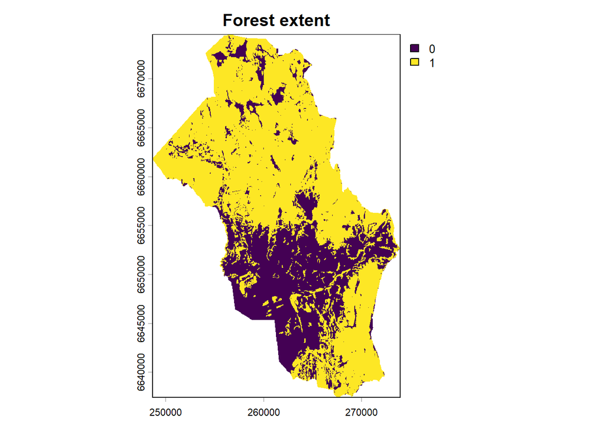

### 7.2 Dominant tree species

Within the forest extent, we set the quality based on the dominant tree species (`treslag`) from the SR16 raster. The SR16 raster has 16-by-16 m pixels with the dominant tree species (i.e. spruce, pine, and broadleaf), we previously computed the proportion of each 50-by-50 m pixel covered by each tree species:

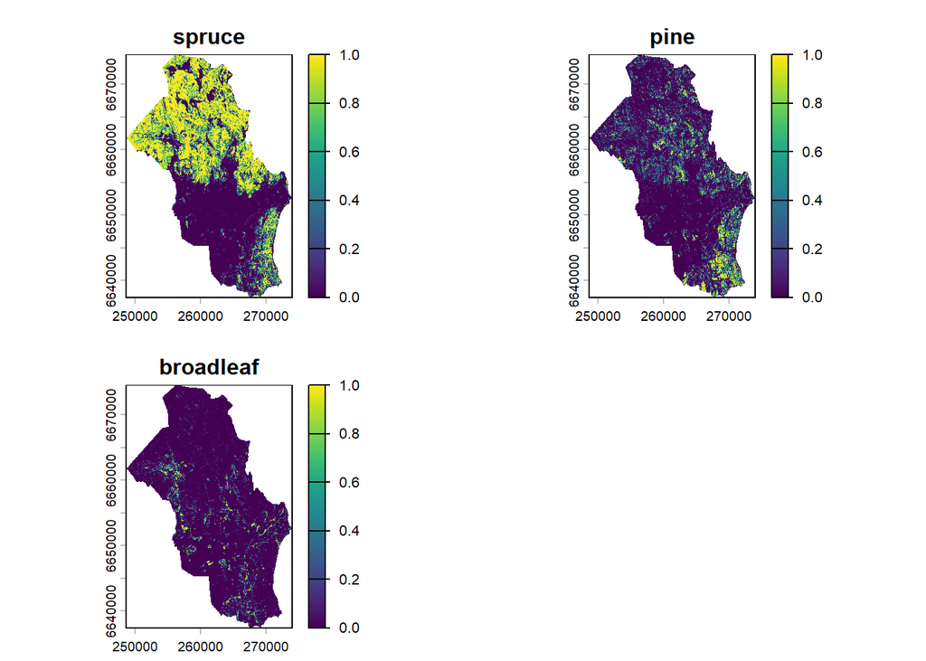

### 7.3 Forest naturalness

Finally, the value of the forest to support species was represented through its naturalness (i.e. [naturskognaerhet](https://www.miljodirektoratet.no/ansvarsomrader/overvaking-arealplanlegging/arealplanlegging/kart-over-naturskog/)). The original naturalness scale ranges from 1 to 7. We merged categories 5, 6, and 7 into a single highest category, because categories 6 and 7 are exceedingly rare. The resulting naturalness layer therefore ranges from 1 to 5. Dividing by 5 gives the model-scale naturalness variable, N, ranging from 0.2 to 1.

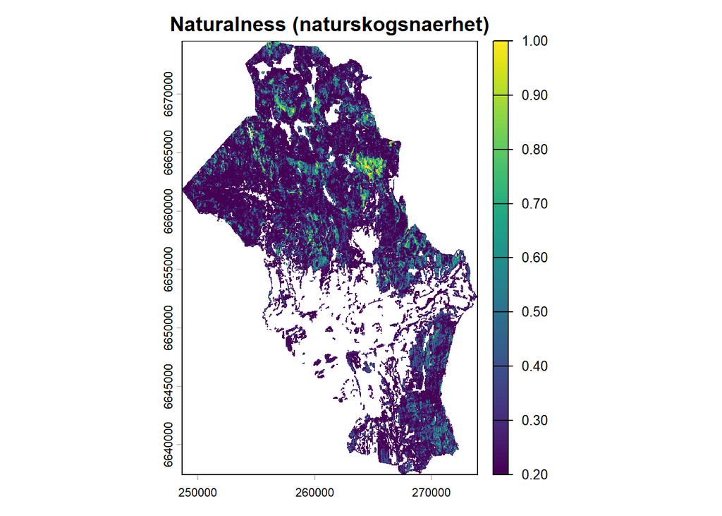

## 8. Spatial units

We used a spatial resolution of 50-by-50 m aligned with the grid from Statistics Norway for our analysis.

## 9. Analyses

The analysis follows the GreenPlan-approach (Panzacchi et al. 2024) and consists of six components: (1) computation of the habitat quality, (2) computation of the habitat permeability, (3) computation of the reference conditions, (4) network computation on high-performance cluster, (5) integration across dominant tree species, and (6) computation of indicators for different administrative units. We describe these individual steps in detail below.

### 9.1 Habitat quality

Habitat quality describes how suitable each cell is as habitat for each dominant tree species network. In this model, habitat quality depends on two things: forest type and naturalness.

Forest type determines which ecological network the cell mainly contributes to. For example, spruce-dominated forest contributes strongly to the spruce-forest network, while pine-dominated forest contributes strongly to the pine-forest network. Mixed forest contributes partly to several networks. The dominant tree species proportions used for the three dominant tree species networks were shown before. These values translate the SR16 tree-type information into estimated proportions of spruce, pine, and broadleaf forest within each 50-by-50 m pixel. Thus, a pixel covered completely by spruce gets a value of 1 for spruce, similarly for the other forest types. Hence, summed over the forest types, we get the proportion of a forest pixel that is covered by 16-by-16 m dominant tree species pixels, which is maximal 1 and can be smaller than 1.

Naturalness then modifies this dominant tree species contribution. A forest cell with high naturalness receives a higher quality value than a similar forest cell with low naturalness.

Thus, within the forest mask, for each forest type, the final habitat quality is calculated as:

$$Q_k = T_k * N$$

where $Q_k$ is the habitat quality for dominant tree species $k$, $T_k$ is the proportion of the pixel covered by this dominant tree species (DTS), and $N$ is the naturalness value. This means that a cell must have both a relevant forest type and sufficient naturalness to receive high habitat quality.

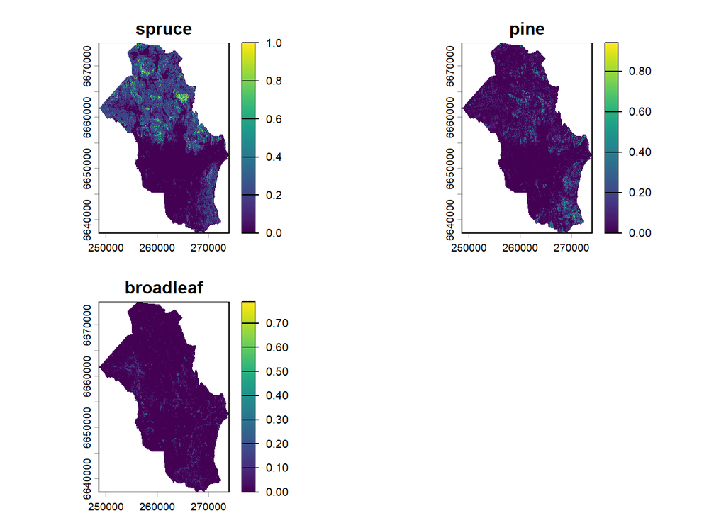

The resulting quality maps should be interpreted as type-specific habitat layers. They indicate where the landscape contains forest that is both compositionally relevant and sufficiently natural for each forest-associated community. High-quality cells are expected to function more strongly as habitat nodes in the connectivity model. Low-quality cells may still contribute to movement, but they contribute less as habitat.

### 9.2 Habitat permeability

Habitat permeability describes how easily organisms can move through each cell. It is related to habitat quality, but it represents a different ecological role. Habitat quality describes how suitable a cell is as habitat, while permeability describes how much the cell facilitates movement through the landscape.

In the model, permeability is less strongly tied to exact forest type than habitat quality. The reasoning is that a forest cell that is not the preferred habitat type may still be easier to move through than open or non-forest matrix. For example, pine forest may not be high-quality habitat for spruce-forest-associated communities, but it may still provide more suitable movement conditions than non-forest land.

We therefore start with a matrix_perm permeability for the non-forest matrix: $B = 0.25$. This value means that areas outside the forest habitat extent are not treated as completely impermeable. They still allow some movement, but less than forested areas.

```r
matrix_perm = 0.25
```

Within the forest extent, permeability is based on the same broad dominant tree species information used for habitat quality, but the dominant tree species proportions are compressed using a cube-root transformation. Thus, just as for habitat quality, as more of the matching forest type is available the permeability increases. However, the compression implies that even a little of the matching forest type contributes disproportionally to permeability.

This reflects the idea that the amount of matching forest types matters less for movement than for habitat use. A cell with little of the ‘right’ forest type may be poor habitat, but it can still function as part of the movement landscape. Furthermore, even in the absence of the matching forest type, we assign a minimum value of 0.01 to all pixels with forest.

We compressed the dominant tree species contribution to permeability using a cube-root transformation (given a minimum value of a proportion of 0.01 for the focal type within forests, even when the focal forest type was not recorded):

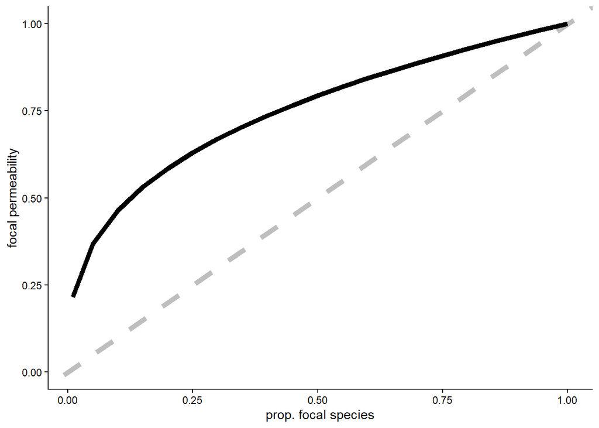

Thus, the compressed permeability value $C_k$ is:
$$C_k = max(0.01, T_k)^{1/3}$$
where $T_k$ is the dominant tree species proportion and $C_k$ is the compressed permeability value, with 0.01 being the minimum value within the forest (even in the absence of the focal type: $T_k=0$).

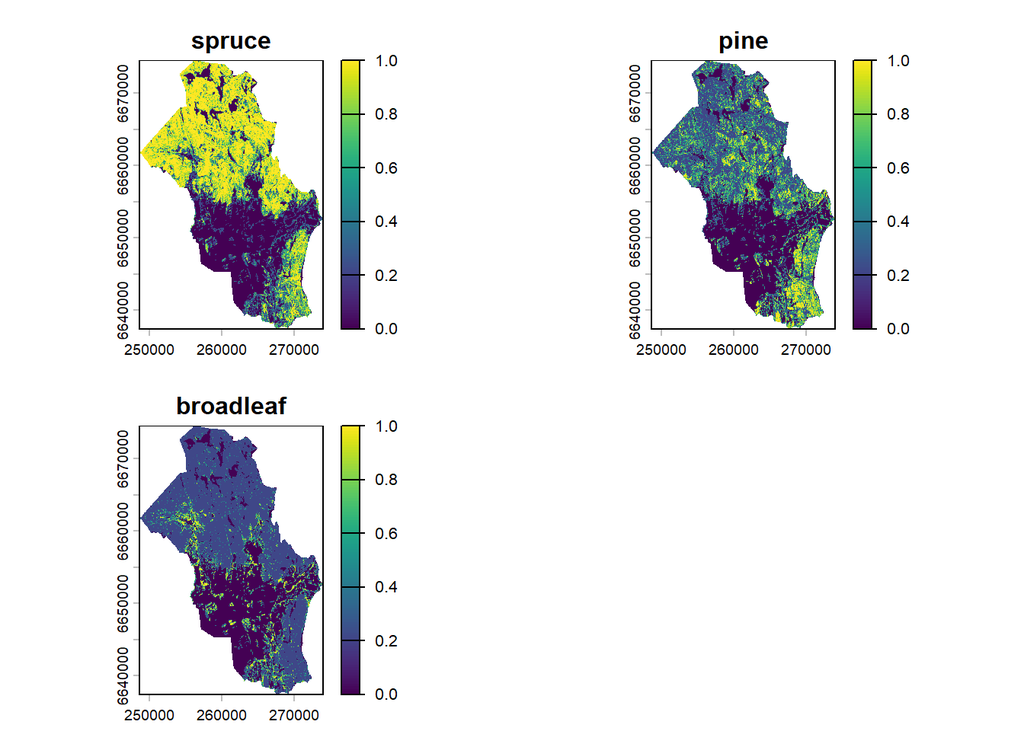

Within the forest, each forest type receives at least a small permeability contribution for all forest-associated networks. This means that even if a forest cell is not classified as containing forest type $k$, it is still treated as somewhat more permeable than non-forest matrix simply because it is forest. The cube-root transformation then compresses the differences among the amount of matching forest type, so that low availability of matching forest type can still contribute to movement, while high-availability of the matching forest type remain most permeable.

Final permeability is calculated by adding a forest-related permeability contribution on top of the baseline matrix permeability:

$$P_k = B + 0.75 * C_k * N$$

where $P_k$ is the final permeability for dominant tree species network $k$, $B$ is the baseline matrix permeability, $C_k$ is the compressed dominant tree species permeability value, and $N$ is naturalness scaled from 0.2 to 1.

The matrix_perm permeability is set to 0.25. This means that the non-forest matrix is not treated as completely impermeable, but as having a low background permeability.

The forest contribution is multiplied by naturalness, so more natural forest receives higher permeability than less natural forest. However, naturalness ranges from 0.2 to 1, so even forest with low naturalness remains more permeable than the non-forest matrix. If naturalness were allowed to approach 0, low-naturalness forest would effectively fall back to the baseline matrix permeability, which would remove the distinction between degraded forest and non-forest.

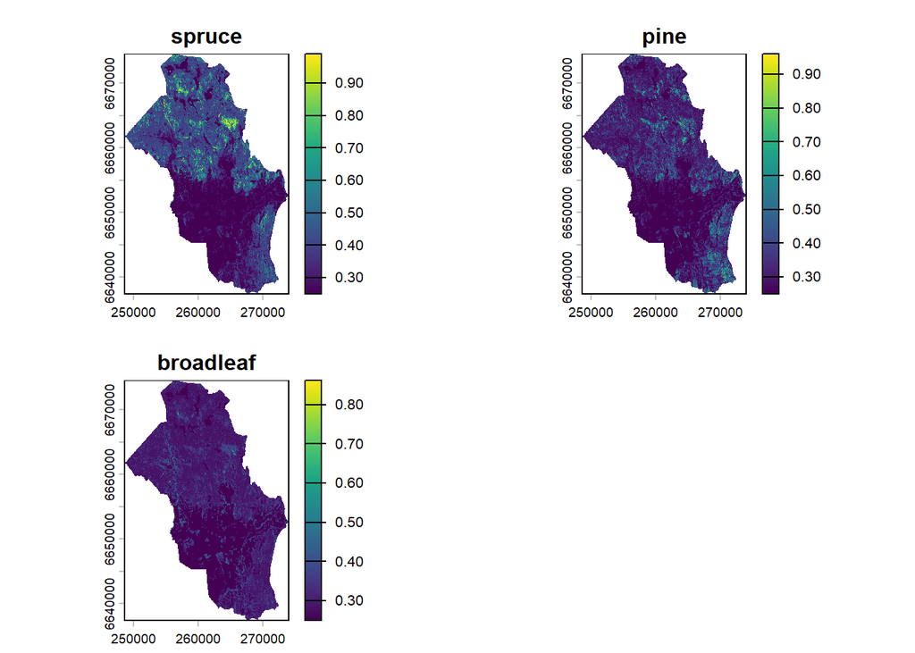

```r
perm <- ((DTS_perm * nat) * 0.75) + matrix_perm
perm <- ifel(perm>0.99, 0.99, perm)
perm <- focus(ifel(is.na(perm), matrix_perm, perm))

if (write_rasters){
  for (i in c(1:3)){
    writeRaster(perm[[i]], file=here("data/inputs_julia", paste0(tree_species[i], "_forest_permeability.tif")), overwrite=F)
  }
}

plot(perm)
```

#### Recap of the permeability calculation

The permeability calculation has four steps.

First, each forest cell receives an estimated dominant tree species proportion, $T_k$, for each dominant tree species network $k$. This is the same basic dominant tree species information used in the habitat quality calculation.

Second, this dominant tree species proportion is transformed into a compressed permeability value:

$$C_k = max(0.01, T_k)^{1/3}$$

The minimum value of 0.01 means that all forest cells receive at least a small forest-related permeability contribution for each dominant tree species network, even when that forest type is not present in the cell. The cube-root transformation compresses differences among the proportion of a forest type, so pixels with relatively little of the matching forest type are still treated as relatively permeable, while a large amount of the matching forest type remain most permeable. Note that the minimum value for forest is 0.01, thus the permeability of a forest pixels is $0.75 * 0.01^{1/3} * N \leq 0.162$ higher than the baseline ($0.25$). In other words, the contribution from a non-matching forest pixel is about 65% above the matrix (0.412 vs. 0.25 in the matrix), if it is highly natural.

Third, the compressed dominant tree species permeability is multiplied by naturalness, N. The original naturalness layer is reduced to five ordered categories and rescaled by dividing by 5, giving values from 0.2 to 1.

Fourth, the forest-related permeability contribution is added on top of the baseline matrix permeability:

$$P_k = B + 0.75 * C_k * N$$

where B = 0.25. The factor 0.75 ensures that when $C_k$ = 1 and N = 1, the final permeability reaches 1 (in practice capped to 0.99 for numerical reasons). Non-forest matrix has permeability 0.25, while forest cells receive additional permeability depending on forest type and naturalness.

In short, the permeability layer still gives the highest permeability to forest that both matches the focal dominant tree species network and has high naturalness, but is less sensitive to the amount of the matching dominant tree species.

### 9.3 Reference condition

For ecosystem accounting, the current condition of an ecosystem is usually interpreted relative to a reference condition. The reference condition represents the state against which current ecosystem condition can be compared. In this analysis, we define the reference condition as a landscape where all existing forest has maximum naturalness (see: Bjørkvoll et al. 2025).

This does not mean that the whole landscape is assumed to become forest. The forest extent and dominant tree species composition are kept the same as in the current-condition model. What changes is the naturalness value. In the reference condition, naturalness is set to 1 for all forest cells. This does not imply that all forest is old forest, also a young forest can be highly natural.

The reference condition therefore answers a specific question: what would the connectivity model return if the same forest landscape had natural forest condition everywhere within the forest mask?

This reference is useful because it separates two things that are otherwise combined in the current-condition outputs. The first is the spatial structure and composition of the forest landscape: where forest occurs, and whether it is spruce, pine, or broadleaf forest. The second is the condition of that forest, represented by naturalness. By setting naturalness to 1, the reference condition keeps the forest landscape fixed but removes degradation in forest condition.

To compute the reference condition, we recreate the habitat quality and permeability layers without reducing them by current naturalness. For habitat quality, this means:

$$Q_{k,ref} = T_k$$
because N = 1 in the reference condition.

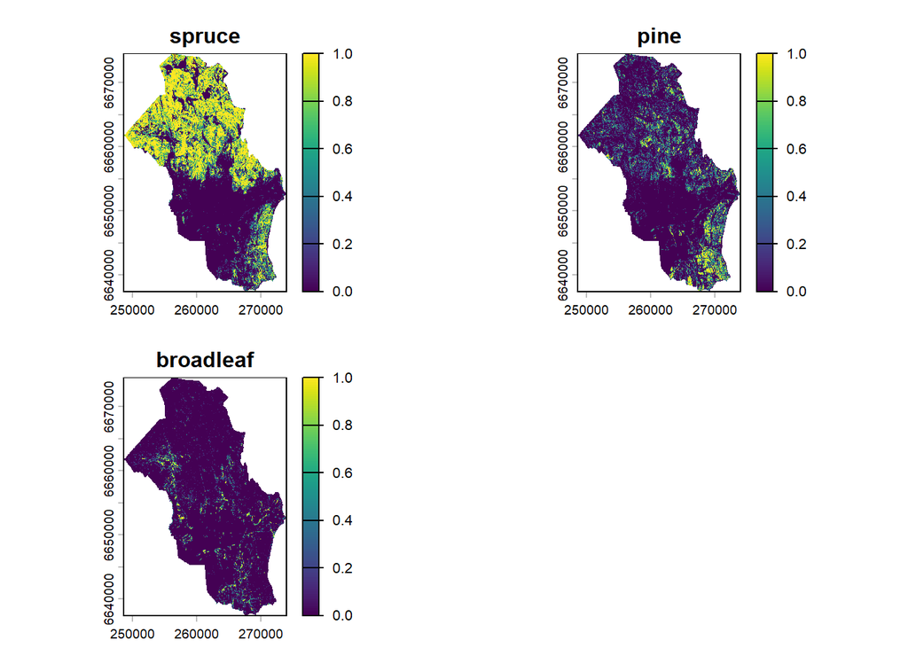

```r
quality_ref <- forest_ext * DTS
names(quality_ref) <- tree_species
quality_ref <- focus(ifel(is.na(quality_ref), 0, quality_ref))

if (write_rasters){
  for (i in c(1:3)){
    writeRaster(quality_ref[[i]], file=here("data/inputs_julia", paste0(tree_species[i], "_forest_ref_quality.tif")), overwrite=F)
  }
}

plot(quality_ref)
```

For permeability, the reference condition is:
$$P_{k,ref} = B + 0.75 * C_k$$
again because N = 1.

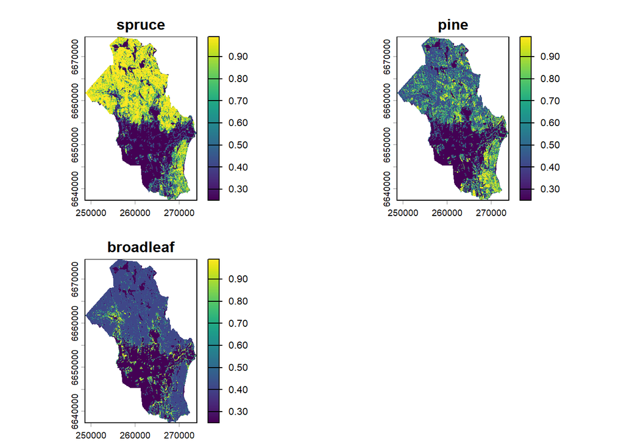

```r
perm_ref <- DTS_perm * 0.75 + matrix_perm
perm_ref <- ifel(perm_ref>0.99, 0.99, perm_ref)
perm_ref <- focus(ifel(is.na(perm_ref), matrix_perm, perm_ref))

if (write_rasters){
  for (i in c(1:3)){
    writeRaster(perm_ref[[i]], file=here("data/inputs_julia", paste0(tree_species[i], "_forest_ref_permeability.tif")), overwrite=F)
  }
}

plot(perm_ref)
```

The reference-condition connectivity output is not intended as a prediction of a realistic future landscape. It is a model-based benchmark. It represents the connectivity that would be expected if the existing forest landscape were in the best naturalness condition represented by the input data.

### 9.4 Network computation

ConScape was used to compute the connectivity outputs from the habitat-quality and permeability layers. ConScape is a Julia library for landscape connectivity modelling that can compute connected-habitat and movement-flow-related metrics for large raster landscapes (Van Moorter, Kivimäki, Noack, et al. 2023).

The model was run separately for each dominant tree species network: spruce, pine, and broadleaf forest. For each network, the corresponding habitat quality layer describes where suitable habitat is located, while the permeability layer describes how easily movement can occur through the landscape.

#### Distance decay

ConScape uses ecological distance to describe how strongly cells are connected through the permeability surface. For the connected-habitat computation, this distance is transformed into a proximity value between 0 and 1. In this analysis we used a simple exponential distance-decay function:

$$k(d) = exp(-\alpha \times d)$$

where $k(d)$ is the proximity, or remaining connection strength, at ecological distance $d$, and $\alpha$ controls how quickly connection strength declines with distance.

A smaller $\alpha$ means that habitat influence extends farther through the landscape. A larger $\alpha$ means that connectivity is more local. In this document, the distance-decay function should be interpreted as a generic connectivity assumption for forest-associated communities, not as a dispersal kernel for a specific species.

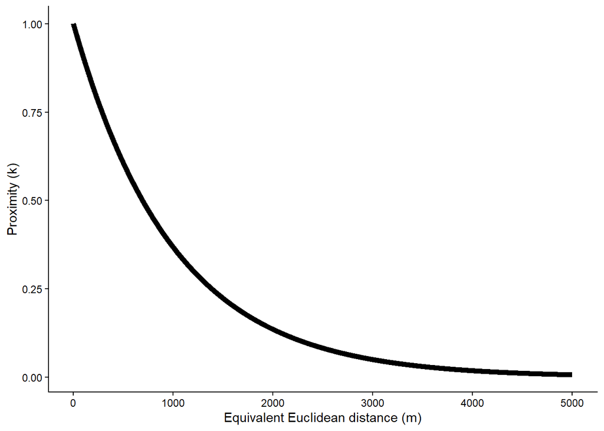

The decay is applied to ecological distance rather than simple Euclidean distance. This means that the effective connection between two cells depends both on how far apart they are and on the permeability of the landscape between them. High-permeability areas maintain stronger connections over distance, while low-permeability areas reduce connection strength more quickly.

#### Run on high-performance cluster

We run the equivalent to the following code outside this document on a high-performance computing cluster.

```julia
using ConScape#fix/threaded-window-channel-pool
using Rasters, ArchGDAL
using GLMakie

# 0. Preamble  -------------------
nothing

using Pkg
Pkg.activate(@__DIR__)
Pkg.instantiate()

indir = "data/inputs_julia/"

# 1. Parameters  -------------------
# weighing of cost and number of paths:
theta = 1.0

# distance decay
optimal_r = 0.659 # ecological distance to Euclidean distance equivalent
alpha = 1 / 1000
Alpha = alpha .* optimal_r

# size of the moving window
res = 50
radius = Int(5_000 / res)

centersize = 20

forest_type = 1
forest_types = ["spruce", "pine", "broadleaf"]

for forest_type in 1:3
    ### * Load raster files
    steplikelihood = Raster(joinpath(indir, "forest_permeability.tif"), missingval=NaN)
    steplikelihood = steplikelihood[Rasters.Band(forest_type)]
    quality = Raster(joinpath(indir, "forest_quality.tif"), missingval=NaN)
    quality = quality[Rasters.Band(forest_type)]

    rast = RasterStack((; steplikelihood, quality))
    # Make sure all missing values are shared between steplikelihood and quality
    mask!(rast; with=rast)
    Rasters.rplot(rast)

    ### * Set up
    movement = RandomisedShortestPath(;
        theta=theta,
        proximity_measure=ExpectedCost(),
        distance_transformation=ExpMinusAlpha(Alpha)
    );

    measures = (; ch=FunctionalHabitat(),
                betk=Betweenness(QualityAndProximityWeighted()),
                )

    ### * Run
    #Threads.nthreads()

    problem = ConScapeProblem(; measures, movement)

    [centersize, radius]
    windowed_problem = WindowedProblem(problem;
        centersize=centersize, buffer=radius, threaded=true
    )

    result = solve(windowed_problem, rast)

    write(("outputs_julia/" * forest_types[forest_type] * "_functionality.tif"), result["ch"]; force=true)
    write(("outputs_julia/" * forest_types[forest_type] * "_corridors.tif"), result["betk"]; force=true)

    ### * Load raster files - reference
    steplikelihood = Raster(joinpath(indir, "forest_ref_permeability.tif"), missingval=NaN)
    steplikelihood = steplikelihood[Rasters.Band(forest_type)]
    quality = Raster(joinpath(indir, "forest_ref_quality.tif"), missingval=NaN)
    quality = quality[Rasters.Band(forest_type)]
    rast = RasterStack((; steplikelihood, quality))
    mask!(rast; with=rast)
    measures = (; ch=FunctionalHabitat(),)
    problem = ConScapeProblem(; measures, movement)
    windowed_problem = WindowedProblem(problem; centersize=centersize, buffer=radius, threaded=true)
    result = solve(windowed_problem, rast)
    write(("outputs_julia/" * forest_types[forest_type] * "_ref_functionality.tif"), result["ch"]; force=true)
end
```

These national-scale ConScape computations were run outside this document on a high-performance computing cluster. This document loads the resulting connected-habitat and corridor rasters and shows how they are interpreted and aggregated.

### 9.5 Integration across dominant tree species

ConScape produces several connectivity outputs. In this document we focus on three types of output: connected habitat, corridors, and reference state for ecosystem accounting.

Connected habitat describes where habitat contributes to the broader connected network. A cell with high connected habitat is not only suitable habitat locally, but is also well connected to other suitable habitat through the surrounding landscape.

Corridors describe areas that are important for movement between habitat areas. These areas may or may not be high-quality habitat themselves. Their importance comes from their role in linking other parts of the network.

We first load the connected-habitat maps for the three dominant tree species networks:

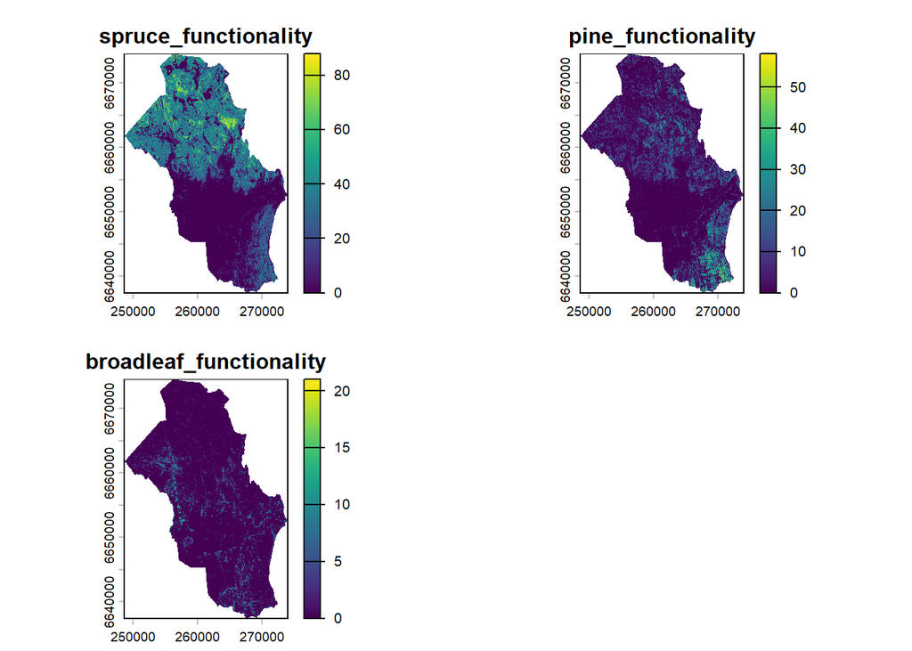

These maps show connected habitat separately for spruce, pine, and broadleaf forest. Differences among the maps reflect the distribution of each forest type, the naturalness of those forests, and the permeability of the surrounding landscape.

To obtain a single forest-level connected-habitat layer, we sum the outputs across the three dominant tree species networks:

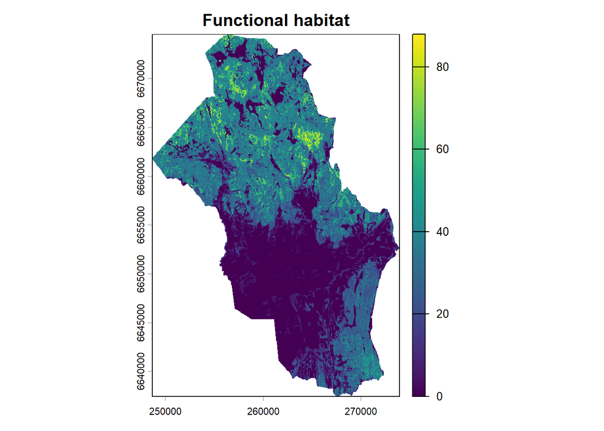

```r
func <- app(focus(func), sum)
plot(sqrt(func), col = viridis(100, option = "viridis"), main="Functional habitat")
```

This combined layer should be interpreted as an aggregate indicator of connected natural forest habitat. It is not a separate model run for a generic forest type. Instead, it summarizes the type-specific networks into one forest-level map.

We use the same approach for corridors. First, we load the corridor outputs for the three dominant tree species networks:

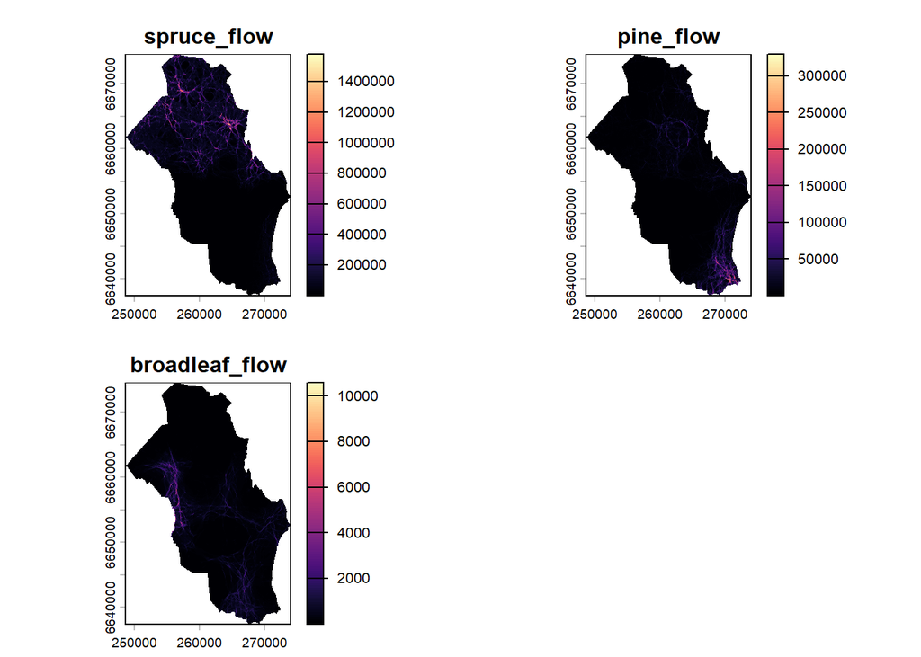

These maps show where each dominant tree species network depends on movement through the landscape. A high corridor value does not necessarily mean that the cell is high-quality habitat. It means that the cell contributes to connecting habitat elsewhere.

We then sum the corridor outputs across forest types to obtain a forest-level corridor layer:

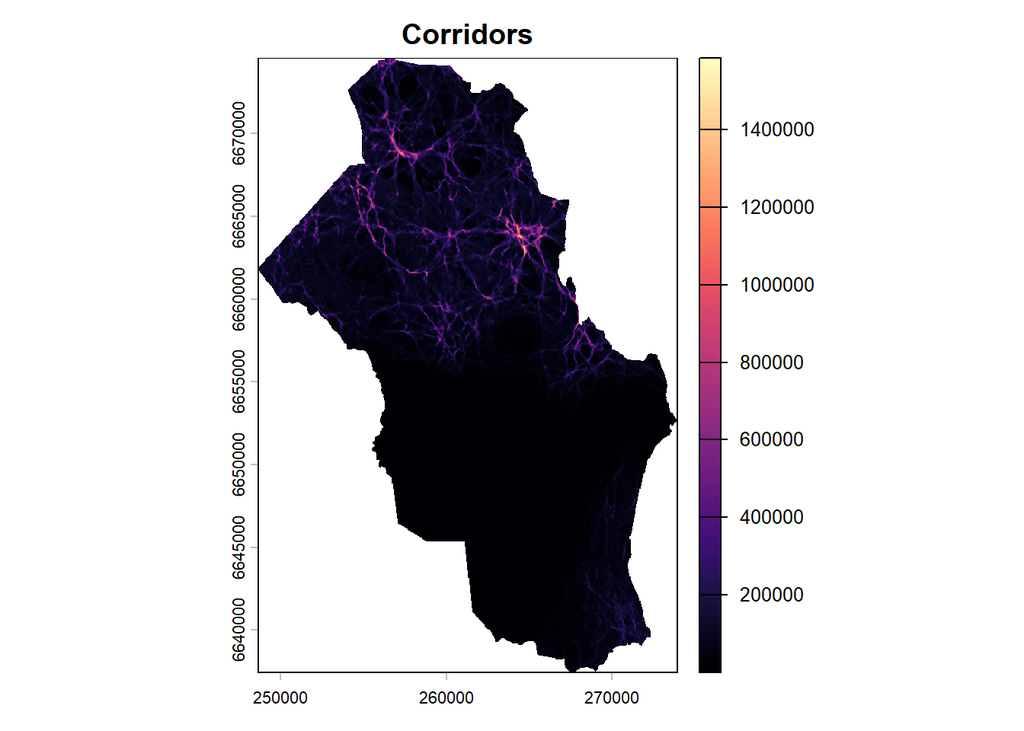

```r
corridors <- app(corridors, sum)
plot(corridors, col = viridis(100, option = "magma"), main="Corridors")
```

The forest-level corridor map highlights areas that contribute to movement across one or more dominant tree species networks. These areas are useful to distinguish from connected habitat, because they may represent connective landscape rather than habitat nodes.

### 9.6 Connectivity indicators

The reference condition allows the current connectivity output to be expressed as a condition indicator. We calculate this by comparing connected habitat under the current condition with connected habitat under the reference condition.

The connected habitat under the reference condition aggregated across forest types is:

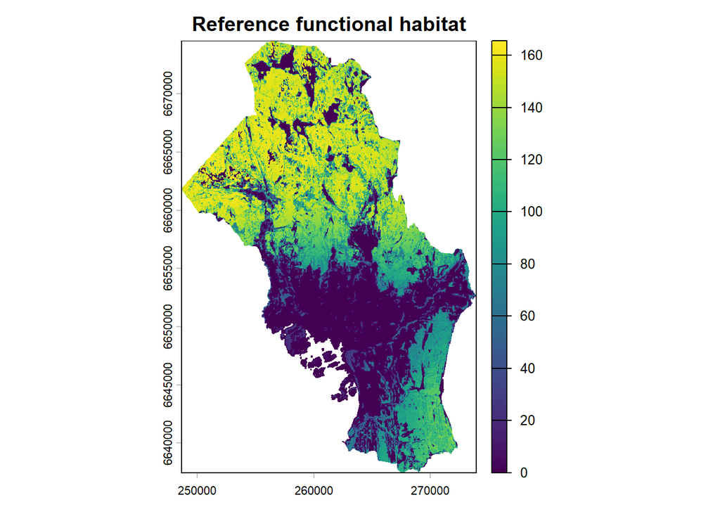

```r
ref <- here("data/outputs_julia", paste0(tree_species, "_ref_functionality.tif"))
ref <- focus(rast(ref))

ref <- app(ref, sum)
plot(sqrt(ref), col = viridis(100, option = "viridis"), main="Reference functional habitat")
```

This map shows the square root of the cell-level connected-habitat raster. It is a diagnostic visualization, not a map of ECH. ECH is calculated only after summing connected habitat across the accounting area.

For the summary indicator, we use equivalent connected habitat (ECH) rather than raw connected habitat Van Moorter, Kivimäki, Panzacchi, et al. (2023). ECH is a summary statistic for an area, not a cell-level raster quantity. It is calculated from the total connected habitat within the area:

$$ECH = \sqrt{\sum H}$$

where H is the connected habitat metric, also known as habitat functionality (Van Moorter, Kivimäki, Panzacchi, et al. 2023).

Because ECH is calculated after aggregation, it cannot be mapped directly at the pixel level. However, we often plot the square root of the connected-habitat raster as a visual transformation. This root-transformed map is not ECH, because $\sqrt{\sum H}$ is not the same as $\sum \sqrt{H}$. It is only a diagnostic visualization that puts the cell-level connected-habitat values on a scale that is closer to the area units of ECH and is easier to visually interpret.

The connectivity condition indicator is calculated as the ratio between current and reference ECH:

$$I_{ECH} = \frac{ECH_{current}}{ECH_{reference}}$$

or equivalently:

$$I_{ECH} = \frac{\sqrt{\sum H_{current}}}{\sqrt{\sum H_{reference}}}$$

Values close to 1 indicate that current equivalent connected habitat is close to the reference condition. Lower values indicate that current forest condition reduces connected habitat relative to the reference.

```r
EAI <- sqrt(global(func, "sum", na.rm=T)[1,1])/sqrt(global(ref, "sum", na.rm=T)[1,1])
print(paste0("I_ECH = ", round(EAI, 2)))
```

```
[1] "I_ECH = 0.29"
```

The equivalent connected habitat transformation is mainly used for the summary indicator, because it gives a value in area units.

For spatial diagnosis, we map the cell-wise ratio between root-transformed current and reference connected habitat:

$$I_{cell} = \frac{\sqrt{H_{current}}}{\sqrt{H_{reference}}}$$
This map is not the ecosystem-accounting indicator itself. The accounting indicator is calculated after aggregating connected habitat across the accounting area. However, the root-transformed ratio is visually closer to the ECH logic than the raw connected-habitat ratio, because ECH is also based on a square-root transformation. The map should therefore be interpreted as a diagnostic layer showing where current connected habitat is low relative to the reference condition, not as a pixel-level ECH indicator.

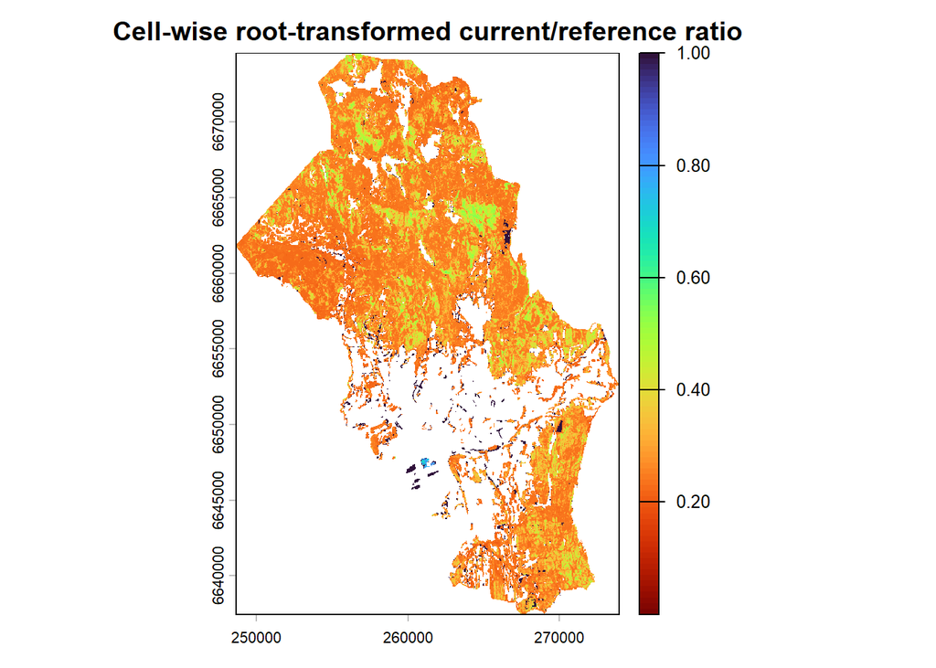

```r
rindicator <- (sqrt(func) + 0.001) / (sqrt(ref) + 0.001)
rindicator <- mask(rindicator, forest_ext, maskvalues=0) # compute the indicator only within the forest extent

plot(ifel(rindicator>1, 1, rindicator),
  col = rev(viridis(100, option = "turbo")),
  main = "Cell-wise root-transformed current/reference ratio")
```

A small constant is added in the code to avoid undefined values where the reference layer is zero or very close to zero.

#### Aggregation across administrative units

```r
if (grepl("/data/", getwd())){
  data_folder <- "/data/R/GeoSpatialData/AdministrativeUnits/Norway_AdministrativeUnits/"
}else{
  data_folder <- "R:/GeoSpatialData/AdministrativeUnits/Norway_AdministrativeUnits/"
}

# conversion from 50-by-50 m pixels to 1000-by-1000 m
conversion_factor <-  (1000/50)*(1000/50)
```

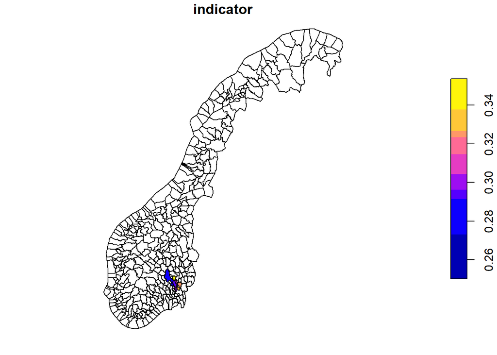

```r
municipality_shp <- sf::st_read(paste0(data_folder, "Original/Norway_Municipalities/Basisdata_0000_Norge_25833_Kommuner_FGDB/Basisdata_0000_Norge_25833_Kommuner_FGDB.gdb"),
  layer = "kommune", quiet = TRUE)

tmp <- terra::extract(func, municipality_shp, fun="sum", na.rm=T)
municipality_shp$variable_km4 <- tmp[,2]/(conversion_factor^2)

tmp <- terra::extract(ref, municipality_shp, fun="sum", na.rm=T)
municipality_shp$ref_km4 <- tmp[,2]/(conversion_factor^2)

municipality_shp$indicator <- sqrt(municipality_shp$variable_km4/municipality_shp$ref_km4)
plot(municipality_shp["indicator"])
```

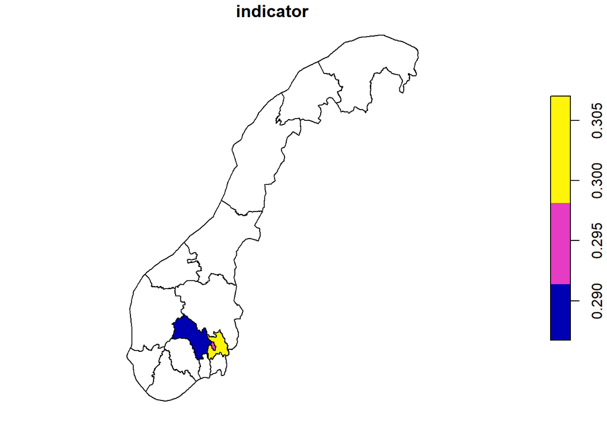

```r
county_shp <- sf::st_read(paste0(data_folder, "Original/Norway_County/Basisdata_0000_Norge_25833_Fylker_FGDB/Basisdata_0000_Norge_25833_Fylker_FGDB.gdb"),
                   layer = "fylke", quiet = TRUE)

tmp <- terra::extract(func, county_shp, fun="sum", na.rm=T)
county_shp$variable_km4 <- tmp[,2]/(conversion_factor^2)

tmp <- terra::extract(ref, county_shp, fun="sum", na.rm=T)
county_shp$ref_km4 <- tmp[,2]/(conversion_factor^2)

county_shp$indicator <- sqrt(county_shp$variable_km4/county_shp$ref_km4)
plot(county_shp["indicator"])
```

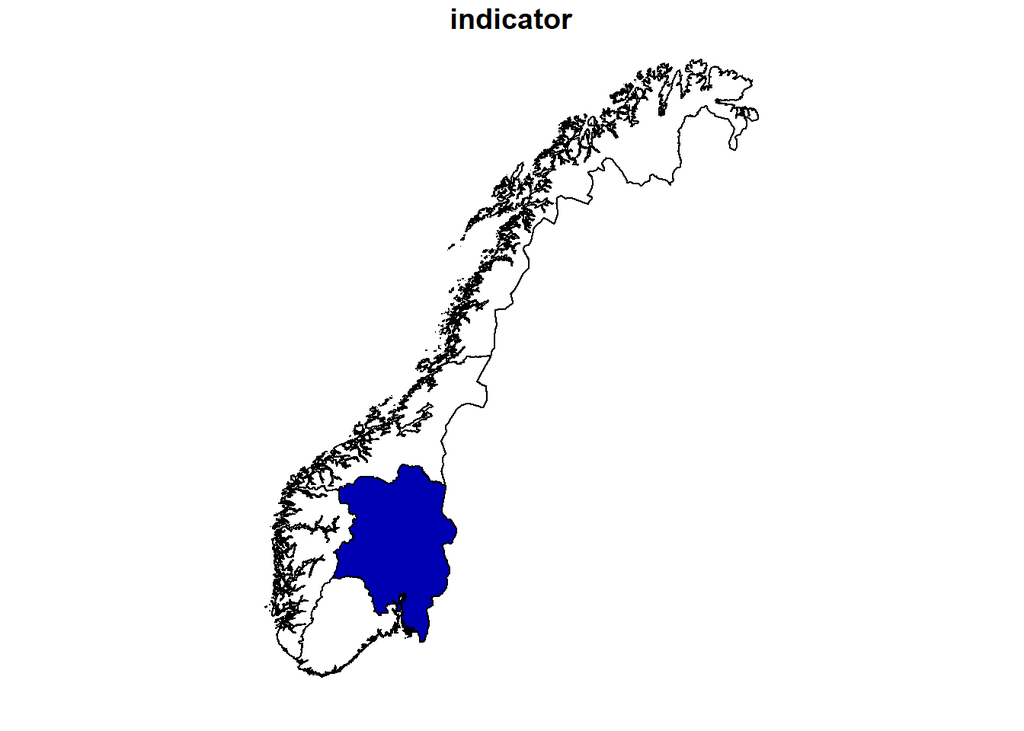

```r
region_shp <- readRDS(here("data/harmonised/", "reg_helperfile.RDS"))

tmp <- terra::extract(func, region_shp, fun="sum", na.rm=T)
region_shp$variable_km4 <- tmp[,2]/(conversion_factor^2)

tmp <- terra::extract(ref, region_shp, fun="sum", na.rm=T)
region_shp$ref_km4 <- tmp[,2]/(conversion_factor^2)

region_shp$indicator <- sqrt(region_shp$variable_km4/region_shp$ref_km4)
plot(region_shp["indicator"])
```

```r
variable_km4 <- global(func, "sum", na.rm=T)[1,1]
ref_km4 <- global(ref, "sum", na.rm=T)[1,1]
indicator <- sqrt(variable_km4/ref_km4)

national_df <- data.frame(objtype="norge", variable_km4=variable_km4, ref_km4=ref_km4, indicator=indicator)

knitr::kable(national_df, digits = 2)
```

| objtype | variable_km4 | ref_km4 | indicator |
| --- | --- | --- | --- |
| norge | 155137517 | 1810975890 | 0.29 |

## 10. Results

Load complete Norwegian data, if precomputed:

```r
if (file.exists(here("data/outputs/", "municipality_account.shp"))){
  municipality_shp <- sf::st_read(here("data/outputs/", "municipality_account.shp"))
  names(municipality_shp)[c(1,11,12,16,17,18)] <- c("objtype", "kommunenummer", "kommunenavn", "variable_km4", "ref_km4", "indicator")
}
if (file.exists(here("data/outputs/", "county_account.shp"))){
  county_shp <- sf::st_read(here("data/outputs/", "county_account.shp"))
  names(county_shp)[c(1,11,12,16,17,18)] <- c("objtype", "fylkesnummer", "fylkesnavn", "variable_km4", "ref_km4", "indicator")
}
if (file.exists(here("data/outputs/", "region_account.shp"))){
  region_shp <- sf::st_read(here("data/outputs/", "region_account.shp"))
  names(region_shp)[c(6,7,8)] <- c("variable_km4", "ref_km4", "indicator")
}
if (file.exists(here("data/outputs/", "national_account.csv"))){
  national_df <- read.csv2(here("data/outputs/", "national_account.csv"))
}
```

Municipal account:

```r
library(gt)

df <- st_drop_geometry(municipality_shp)[,c("objtype", "kommunenummer", "kommunenavn", "variable_km4", "ref_km4", "indicator")]
df$variable_km2 <- sqrt(df$variable_km4)
df$ref_km2 <- sqrt(df$ref_km4)
df <- df[,c("objtype", "kommunenummer", "kommunenavn", "variable_km4", "variable_km2", "ref_km4", "ref_km2", "indicator")]

gt::gt(df) |>
  gt::tab_options(
    container.height = "400px",
    container.overflow.y = TRUE,
    container.overflow.x = TRUE
  )
```

| objtype | kommunenummer | kommunenavn | variable_km4 | variable_km2 | ref_km4 | ref_km2 | indicator |
| --- | --- | --- | --- | --- | --- | --- | --- |
| Kommune | 3419 | Våler | 6.064043e+02 | 2.462528e+01 | 1.340859e+04 | 115.79546729 | 0.2126619 |
| Kommune | 3326 | Hemsedal | 5.450258e+02 | 2.334579e+01 | 2.247154e+03 | 47.40415638 | 0.4924840 |
| Kommune | 4622 | Kvam | 7.219530e+02 | 2.686918e+01 | 2.989861e+03 | 54.67962252 | 0.4913930 |
| Kommune | 5054 | Indre Fosen | 1.934042e+03 | 4.397774e+01 | 9.882957e+03 | 99.41306167 | 0.4423739 |
| Kommune | 4617 | Kvinnherad | 1.086827e+03 | 3.296706e+01 | 4.215679e+03 | 64.92826062 | 0.5077459 |
| Kommune | 4621 | Voss | 3.498433e+03 | 5.914755e+01 | 1.075308e+04 | 103.69705268 | 0.5703880 |
| Kommune | 5031 | Malvik | 4.472643e+02 | 2.114862e+01 | 3.858332e+03 | 62.11547133 | 0.3404727 |
| Kommune | 4036 | Vinje | 4.222244e+03 | 6.497880e+01 | 1.057655e+04 | 102.84235049 | 0.6318292 |
| Kommune | 5035 | Stjørdal | 1.829452e+03 | 4.277210e+01 | 1.284622e+04 | 113.34115279 | 0.3773748 |
| Kommune | 3420 | Elverum | 1.269323e+03 | 3.562756e+01 | 2.725983e+04 | 165.10551187 | 0.2157866 |
| Kommune | 4643 | Årdal | 1.425999e+03 | 3.776241e+01 | 4.225310e+03 | 65.00238708 | 0.5809388 |
| Kommune | 4642 | Lærdal | 2.015883e+03 | 4.489859e+01 | 5.489900e+03 | 74.09386099 | 0.6059691 |
| Kommune | 4644 | Luster | 2.417177e+03 | 4.916479e+01 | 7.195311e+03 | 84.82518116 | 0.5796014 |
| Kommune | 3429 | Folldal | 2.617641e+02 | 1.617913e+01 | 1.082333e+03 | 32.89883304 | 0.4917842 |
| Kommune | 3427 | Tynset | 9.390590e+02 | 3.064407e+01 | 5.736634e+03 | 75.74056907 | 0.4045925 |
| Kommune | 3431 | Dovre | 1.315906e+02 | 1.147130e+01 | 8.952815e+02 | 29.92125578 | 0.3833828 |
| Kommune | 4638 | Høyanger | 1.534948e+03 | 3.917842e+01 | 4.251172e+03 | 65.20101503 | 0.6008866 |
| Kommune | 5036 | Frosta | 7.712868e+01 | 8.782294e+00 | 6.093579e+02 | 24.68517633 | 0.3557720 |
| Kommune | 5037 | Levanger | 1.021805e+03 | 3.196569e+01 | 7.290145e+03 | 85.38234500 | 0.3743829 |
| Kommune | 4631 | Alver | 9.833085e+02 | 3.135775e+01 | 4.728836e+03 | 68.76653369 | 0.4560031 |
| Kommune | 1127 | Randaberg | 1.230658e-01 | 3.508073e-01 | 2.070049e+00 | 1.43876641 | 0.2438251 |
| Kommune | 3424 | Rendalen | 2.777154e+03 | 5.269871e+01 | 2.286447e+04 | 151.21000425 | 0.3485134 |
| Kommune | 1824 | Vefsn | 1.837676e+03 | 4.286812e+01 | 9.947637e+03 | 99.73784094 | 0.4298080 |
| Kommune | 1825 | Grane | 3.433459e+03 | 5.859573e+01 | 1.321585e+04 | 114.96022909 | 0.5097043 |
| Kommune | 5528 | Dyrøy | 3.674362e+02 | 1.916862e+01 | 5.191802e+03 | 72.05416123 | 0.2660308 |
| Kommune | 5538 | Storfjord - Omasvuotna - Omasvuono | 6.107034e+02 | 2.471241e+01 | 4.673771e+03 | 68.36498148 | 0.3614777 |
| Kommune | 4024 | Hjartdal | 3.129775e+03 | 5.594439e+01 | 9.439910e+03 | 97.15919695 | 0.5758013 |
| Kommune | 5520 | Bardu | 1.482904e+03 | 3.850849e+01 | 1.961307e+04 | 140.04665981 | 0.2749690 |
| Kommune | 5532 | Balsfjord | 1.082749e+03 | 3.290516e+01 | 1.957139e+04 | 139.89778670 | 0.2352086 |
| Kommune | 4651 | Stryn | 1.148371e+03 | 3.388763e+01 | 4.678617e+03 | 68.40041751 | 0.4954302 |

[output cut: 327 more lines]

County account:

```r
df <- st_drop_geometry(county_shp)[,c("objtype", "fylkesnummer", "fylkesnavn", "variable_km4", "ref_km4", "indicator")]
df$variable_km2 <- sqrt(df$variable_km4)
df$ref_km2 <- sqrt(df$ref_km4)
df <- df[,c("objtype", "fylkesnummer", "fylkesnavn", "variable_km4", "variable_km2", "ref_km4", "ref_km2", "indicator")]

gt::gt(df) |>
  gt::tab_options(
    container.height = "400px",
    container.overflow.y = TRUE,
    container.overflow.x = TRUE
  )
```

| objtype | fylkesnummer | fylkesnavn | variable_km4 | variable_km2 | ref_km4 | ref_km2 | indicator |
| --- | --- | --- | --- | --- | --- | --- | --- |
| Fylke | 55 | Troms - Romsa - Tromssa | 15639.0736 | 125.05628 | 187797.30 | 433.3559 | 0.2885764 |
| Fylke | 56 | Finnmark - Finnmárku - Finmarkku | 5537.1002 | 74.41169 | 26101.47 | 161.5595 | 0.4605838 |
| Fylke | 33 | Buskerud | 33059.1297 | 181.82170 | 200070.37 | 447.2923 | 0.4064942 |
| Fylke | 40 | Telemark | 50387.5459 | 224.47170 | 222551.08 | 471.7532 | 0.4758245 |
| Fylke | 39 | Vestfold | 2876.2426 | 53.63061 | 33847.98 | 183.9782 | 0.2915052 |
| Fylke | 03 | Oslo | 961.9911 | 31.01598 | 11233.53 | 105.9883 | 0.2926358 |
| Fylke | 15 | Møre og Romsdal | 12677.2495 | 112.59329 | 61247.32 | 247.4820 | 0.4549556 |
| Fylke | 42 | Agder | 48103.9366 | 219.32610 | 264470.02 | 514.2665 | 0.4264834 |
| Fylke | 11 | Rogaland | 10616.2554 | 103.03521 | 39656.17 | 199.1386 | 0.5174046 |
| Fylke | 18 | Nordland - Nordlánnda - Nordlánda - Nordlaante | 49759.4406 | 223.06824 | 199594.49 | 446.7600 | 0.4993022 |
| Fylke | 50 | Trøndelag - Trööndelage | 57521.0940 | 239.83556 | 289274.88 | 537.8428 | 0.4459213 |
| Fylke | 34 | Innlandet - Sisdajve | 41571.3821 | 203.89061 | 450794.80 | 671.4125 | 0.3036741 |
| Fylke | 46 | Vestland | 39430.9885 | 198.57238 | 140517.46 | 374.8566 | 0.5297289 |
| Fylke | 31 | Østfold | 4792.3744 | 69.22698 | 64197.34 | 253.3719 | 0.2732228 |
| Fylke | 32 | Akershus | 8160.7345 | 90.33678 | 122810.97 | 350.4440 | 0.2577781 |

Regional account:

```r
df <- st_drop_geometry(region_shp)[,c("id", "region", "variable_km4", "ref_km4", "indicator")]
df$variable_km2 <- sqrt(df$variable_km4)
df$ref_km2 <- sqrt(df$ref_km4)
df <- df[,c("id", "region", "variable_km4", "variable_km2", "ref_km4", "ref_km2", "indicator")]

gt::gt(df) |>
  gt::tab_options(
    container.height = "400px",
    container.overflow.y = TRUE,
    container.overflow.x = TRUE
  )
```

| id | region | variable_km4 | variable_km2 | ref_km4 | ref_km2 | indicator |
| --- | --- | --- | --- | --- | --- | --- |
| 1 | Nord-Norge | 70278.89 | 265.1017 | 409695.1 | 640.0743 | 0.4141732 |
| 2 | Midt-Norge | 69693.68 | 263.9956 | 348258.8 | 590.1345 | 0.4473482 |
| 3 | Østlandet | 88380.17 | 297.2880 | 847893.0 | 920.8110 | 0.3228545 |
| 4 | Vestlandet | 49594.53 | 222.6983 | 178928.6 | 422.9996 | 0.5264741 |
| 5 | Sørlandet | 101510.07 | 318.6064 | 521787.7 | 722.3487 | 0.4410701 |

National account:

```r
df <- national_df
df$variable_km2 <- sqrt(df$variable_km4)
df$ref_km2 <- sqrt(df$ref_km4)
df <- df[,c("objtype", "variable_km4", "variable_km2", "ref_km4", "ref_km2", "indicator")]

knitr::kable(df, digits = 2)
```

| objtype | variable_km4 | variable_km2 | ref_km4 | ref_km2 | indicator |
| --- | --- | --- | --- | --- | --- |
| norge | 60975694411 | 246932.6 | 370269799730 | 608498 | 0.41 |

## 11. Export file

```r
st_write(municipality_shp, dsn=here("data/outputs/", "municipality_account.shp"), append=F)
st_write(county_shp, dsn=here("data/outputs/", "county_account.shp"), append=F)
st_write(region_shp, dsn=here("data/outputs/", "region_account.shp"), append=F)
write.csv2(national_df, here("data/outputs/", "national_account.csv"), row.names = F)
```

## 12. Author contributions

**CRediT statement**

- Conceptualization: BvM, UJA, RMJ, JN, YKB, MP
- Methodology: BvM
- Data curation: BvM, AK, VB
- Formal analysis: BvM
- Code review: AK
- Writing original draft: BvM
- Writing review & editing: BvM, UJA, RMJ, JN, YKB, MP
- Project administration: EB, MP
- Funding acquisition: EB, MP

**MeRIT attribution**

This part supplements the CRediT statement with more granularity for method section.

**Study design** The study was designed by [BvM, UJA, RMJ, JN, YKB, MP].

**Data processing** Data were curated and processed [BvM].

**Statistical analysis** All analyses were conducted by [BvM] using [R, Julia].

**Visualization** Figures were produced by [BvM].

**Reproducibility** All code was reviewed and validated by [AK].

**Session Info**

This information is mainly aimed at developers that need to recreate the R environment that produced the html. Important note: this information is about the R session that was running when the html was rendered, and if some of the code chunks were not evaluated when the html was rendered, they may have been executed in a different environment.

## References

Bjørkvoll, Eirin Marie, Anders Lorentzen Kolstad, Svein Olav Krøgli, Bram Van Moorter, Wenche Dramstad, and Manuela Panzacchi. 2025. “Strukturell Konnektivitet i økosystemer. Forslag Til Metode Og Bruk Av Indikator i Naturregnskaper.” NINA Rapport. Norsk institutt for naturforskning (NINA). https://api.nva.unit.no/publication/019aca75d290-43e2625e-38ba-4fea-b5cd-3f96f203e394.

Breidenbach, Johannes, Lars T Waser, Misganu Debella-Gilo, Johannes Schumacher, Johannes Rahlf, Marius Hauglin, Stefano Puliti, and Rasmus Astrup. 2021. “National Mapping and Estimation of Forest Area by Dominant Tree Species Using Sentinel-2 Data.” *Canadian Journal of Forest Research* 51 (3): 365–79.

Hauglin, Marius, Ulrika Jansson Asplund, Marie-Claude Jutras-Perreault, Olav Skarpaas, Victor Strimbu, Ken Olaf Storaunet, Anne Sverdrup-Thygeson, Julius Wold, and Hans Ole Ørka. 2025. “Naturskogkart – første Versjon. Bakgrunn Og Metodikk.” Forskningsrapport 11/129/2025. NIBIO Rapport. NIBIO; NIBIO. https://doi.org/10.21350/6s1g-4642.

Panzacchi, Manuela, Bram van Moorter, Markus AK Sydenham, Neri Horntvedt Thorsen, Bernardo Brandão Niebuhr, Erik Stange, Ulrika Jansson, et al. 2024. “Nasjonal Kartlegging Av Grønn Infrastruktur. De første Nasjonale Kartene for Solitære Bier, Elg, Edellauvskog Og Andre Treslag.”

Saura, Santiago, Christine Estreguil, Coralie Mouton, and Mónica Rodrı́guez-Freire. 2011. “Network Analysis to Assess Landscape Connectivity Trends: Application to European Forests (1990–2000).” *Ecological Indicators* 11 (2): 407–16.

Van Moorter, Bram, Ilkka Kivimäki, Andreas Noack, Robin Devooght, Manuela Panzacchi, Kimberly R Hall, Pierre Leleux, and Marco Saerens. 2023. “Accelerating Advances in Landscape Connectivity Modelling with the ConScape Library.” *Methods in Ecology and Evolution* 14 (1): 133–45.

Van Moorter, Bram, Ilkka Kivimäki, Manuela Panzacchi, and Marco Saerens. 2021. “Defining and Quantifying Effective Connectivity of Landscapes for Species’ Movements.” *Ecography* 44 (6): 870–84.

Van Moorter, Bram, Ilkka Kivimäki, Manuela Panzacchi, Santiago Saura, Bernardo Brandão Niebuhr, Olav Strand, and Marco Saerens. 2023. “Habitat Functionality: Integrating Environmental and Geographic Space in Niche Modeling for Conservation Planning.” *Ecology* 104 (7): e4105.